# **Problem Statement**

### Visualizing the prediction:

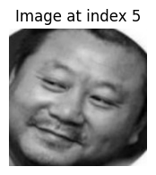

```
1/1 ━━━━━━━━━━━━━━━━━━━━ 2s 2s/step
Predicted Label: 0
True Label: 0
```

[figure not shown]

```
1/1 ━━━━━━━━━━━━━━━━━━━━ 0s 38ms/step
Predicted Label: 1
True Label: 1
```

```python
# Visualizing the predicted and correct label of images from test data
plt.figure(figsize=(2,2))
index = 5
plt.imshow(X_val[index].squeeze(), cmap='gray')
plt.title(f"Image at index {index}")
plt.axis('off')
plt.show()

pred = model_2.predict(X_val_vgg[index].reshape(1, X_val_vgg.shape[1], X_val_vgg.shape[2], X_val_vgg.shape[3]))
pred_label = 1 if pred[0][0] > 0.5 else 0
print('Predicted Label:', pred_label)
print('True Label:', y_val[index])

plt.figure(figsize=(2,2))
index = 23
plt.imshow(X_val[index].squeeze(), cmap='gray')
plt.title(f"Image at index {index}")
plt.axis('off')
plt.show()

pred = model_2.predict(X_val_vgg[index].reshape(1, X_val_vgg.shape[1], X_val_vgg.shape[2], X_val_vgg.shape[3]))
pred_label = 1 if pred[0][0] > 0.5 else 0
print('Predicted Label:', pred_label)
print('True Label:', y_val[index])
```

***Observation: *** The visualized prediction, has predicted both images correctly.

## Model 3: (VGG-16 (Base + FFNN))

```python
# Convert grayscale to RGB-like format for VGG (e.g., (128, 128, 1) → (128, 128, 3))
X_train_vgg = np.repeat(X_train, 3, axis=-1)
X_val_vgg = np.repeat(X_val, 3, axis=-1)
X_test_vgg = np.repeat(X_test, 3, axis=-1)
```

```python
# build model using vgg16 base and add dense layers
model_3 = Sequential()

# add frozen vgg base
model_3.add(vgg_model)

# flatten output from conv layers
model_3.add(Flatten())

# add dense layers
model_3.add(Dense(128, activation='relu'))
model_3.add(Dropout(rate=0.3))
model_3.add(Dense(64, activation='relu'))

# add final output layer
model_3.add(Dense(1, activation='sigmoid'))
```

```python
# set optimizer and compile model
opt = Adam(learning_rate=0.001)

model_3.compile(
    optimizer=opt,
    loss=keras.losses.BinaryCrossentropy(),
    metrics=["accuracy", "Precision"]
)

# show model summary
model_3.summary()
```

```
Model: "sequential_2"
```

```
┏━━━━━━━━━━━━━━━━━━━━━━━━━━━━━━━━━┳━━━━━━━━━━━━━━━━━━━━━━━━┳━━━━━━━━━━━━━━━┓
┃ Layer (type)                    ┃ Output Shape           ┃       Param # ┃
┡━━━━━━━━━━━━━━━━━━━━━━━━━━━━━━━━━╇━━━━━━━━━━━━━━━━━━━━━━━━╇━━━━━━━━━━━━━━━┩
│ vgg16 (Functional)              │ (None, 6, 6, 512)      │    14,714,688 │
├─────────────────────────────────┼────────────────────────┼───────────────┤
│ flatten_2 (Flatten)             │ (None, 18432)          │             0 │
├─────────────────────────────────┼────────────────────────┼───────────────┤
│ dense_3 (Dense)                 │ (None, 128)            │     2,359,424 │
├─────────────────────────────────┼────────────────────────┼───────────────┤
│ dropout (Dropout)               │ (None, 128)            │             0 │
├─────────────────────────────────┼────────────────────────┼───────────────┤
│ dense_4 (Dense)                 │ (None, 64)             │         8,256 │
├─────────────────────────────────┼────────────────────────┼───────────────┤
│ dense_5 (Dense)                 │ (None, 1)              │            65 │
└─────────────────────────────────┴────────────────────────┴───────────────┘
```

```
 Total params: 17,082,433 (65.16 MB)
```

```
 Trainable params: 2,367,745 (9.03 MB)
```

```
 Non-trainable params: 14,714,688 (56.13 MB)
```

```python
# training setup
epochs = 10
batch_size = 32

# Set run_eagerly to True to avoid ValueError with tf.function and variable creation
model_3.run_eagerly = True

# train model using generator
history_3 = model_3.fit(
    train_datagen.flow(X_train_vgg, y_train, batch_size=batch_size, seed=42, shuffle=False),
    steps_per_epoch=X_train_vgg.shape[0] // batch_size,
    epochs=epochs,
    validation_data=(X_val_vgg, y_val),
    verbose=1
)
```

```
13/13 ━━━━━━━━━━━━━━━━━━━━ 28s 1s/step - Precision: 0.7547 - accuracy: 0.7987 - loss: 1.7880 - val_Precision: 1.0000 - val_accuracy: 1.0000 - val_loss: 7.3719e-08
13/13 ━━━━━━━━━━━━━━━━━━━━ 1s 53ms/step - Precision: 1.0000 - accuracy: 1.0000 - loss: 3.3131e-14 - val_Precision: 1.0000 - val_accuracy: 1.0000 - val_loss: 2.4326e-10
13/13 ━━━━━━━━━━━━━━━━━━━━ 8s 600ms/step - Precision: 1.0000 - accuracy: 1.0000 - loss: 9.7204e-10 - val_Precision: 1.0000 - val_accuracy: 1.0000 - val_loss: 8.8677e-19
13/13 ━━━━━━━━━━━━━━━━━━━━ 1s 61ms/step - Precision: 1.0000 - accuracy: 1.0000 - loss: 8.2649e-27 - val_Precision: 1.0000 - val_accuracy: 1.0000 - val_loss: 3.6192e-18
13/13 ━━━━━━━━━━━━━━━━━━━━ 7s 575ms/step - Precision: 1.0000 - accuracy: 1.0000 - loss: 4.4557e-21 - val_Precision: 1.0000 - val_accuracy: 1.0000 - val_loss: 4.7933e-14
13/13 ━━━━━━━━━━━━━━━━━━━━ 1s 49ms/step - Precision: 1.0000 - accuracy: 1.0000 - loss: 0.0000e+00 - val_Precision: 1.0000 - val_accuracy: 1.0000 - val_loss: 6.6939e-14
13/13 ━━━━━━━━━━━━━━━━━━━━ 7s 562ms/step - Precision: 1.0000 - accuracy: 1.0000 - loss: 1.5914e-21 - val_Precision: 1.0000 - val_accuracy: 1.0000 - val_loss: 7.3189e-13
13/13 ━━━━━━━━━━━━━━━━━━━━ 1s 51ms/step - Precision: 1.0000 - accuracy: 1.0000 - loss: 7.8432e-32 - val_Precision: 1.0000 - val_accuracy: 1.0000 - val_loss: 7.9991e-13
13/13 ━━━━━━━━━━━━━━━━━━━━ 7s 566ms/step - Precision: 1.0000 - accuracy: 1.0000 - loss: 4.3181e-21 - val_Precision: 1.0000 - val_accuracy: 1.0000 - val_loss: 1.4964e-12
13/13 ━━━━━━━━━━━━━━━━━━━━ 1s 49ms/step - Precision: 1.0000 - accuracy: 1.0000 - loss: 7.9480e-15 - val_Precision: 1.0000 - val_accuracy: 1.0000 - val_loss: 1.5310e-12
```

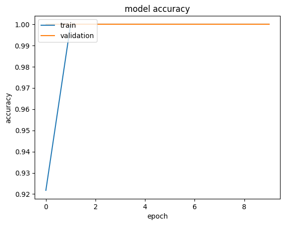

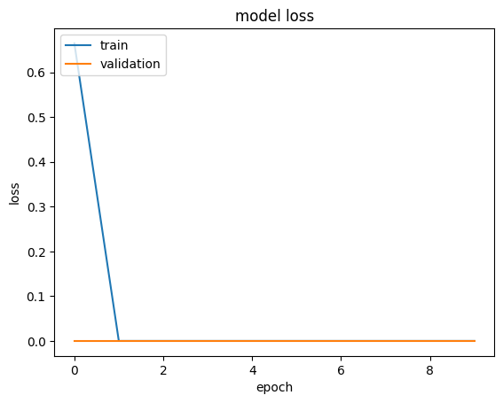

```python
# plot accuracy curves
plt.plot(history_3.history['accuracy'])
plt.plot(history_3.history['val_accuracy'])
plt.title('model accuracy')
plt.ylabel('accuracy')
plt.xlabel('epoch')
plt.legend(['train', 'validation'], loc='upper left')
plt.show()

# plot loss curves
plt.plot(history_3.history['loss'])
plt.plot(history_3.history['val_loss'])
plt.title('model loss')
plt.ylabel('loss')
plt.xlabel('epoch')
plt.legend(['train', 'validation'], loc='upper left')
plt.show()
```

**Observation:** There was not change in Model 3: (VGG-16 (Base + FFNN))

```python
# evaluate on train data
model_3_train_perf = model_performance_classification(model_3, X_train_vgg, pd.Series(y_train))
print("train performance metrics")
print(model_3_train_perf)

plot_confusion_matrix(model_3, X_train_vgg, pd.Series(y_train))

# evaluate on validation data
model_3_valid_perf = model_performance_classification(model_3, X_val_vgg, pd.Series(y_val))
print("validation performance metrics")
print(model_3_valid_perf)

plot_confusion_matrix(model_3, X_val_vgg, pd.Series(y_val))
```

[output not shown]

```
14/14 ━━━━━━━━━━━━━━━━━━━━ 2s 161ms/step
train performance metrics
   Accuracy  Recall  Precision  F1 Score
0       1.0     1.0        1.0       1.0
14/14 ━━━━━━━━━━━━━━━━━━━━ 2s 162ms/step
```

```
3/3 ━━━━━━━━━━━━━━━━━━━━ 1s 174ms/step
validation performance metrics
   Accuracy  Recall  Precision  F1 Score
0       1.0     1.0        1.0       1.0
3/3 ━━━━━━━━━━━━━━━━━━━━ 1s 172ms/step
```

#### Visualizing the predictions

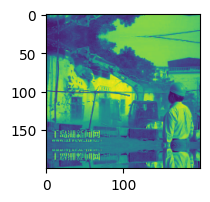

```
1/1 ━━━━━━━━━━━━━━━━━━━━ 1s 522ms/step
predicted label: 1
true label: 1
```

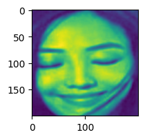

```
1/1 ━━━━━━━━━━━━━━━━━━━━ 0s 90ms/step
predicted label: 0
true label: 0
```

```python
# prediction 1 - index 7
plt.figure(figsize=(2, 2))
plt.imshow(X_val[7])
plt.show()

pred = model_3.predict(X_val_vgg[7].reshape(1, X_val_vgg.shape[1], X_val_vgg.shape[2], X_val_vgg.shape[3]))
pred_label = 1 if pred[0][0] > 0.5 else 0
true_label = y_val[7]

print('predicted label:', pred_label)
print('true label:', true_label)

# prediction 2 - index 15
plt.figure(figsize=(2, 2))
plt.imshow(X_val[15])
plt.show()

pred = model_3.predict(X_val_vgg[15].reshape(1, X_val_vgg.shape[1], X_val_vgg.shape[2], X_val_vgg.shape[3]))
pred_label = 1 if pred[0][0] > 0.5 else 0
true_label = y_val[15]

print('predicted label:', pred_label)
print('true label:', true_label)
```

## Model 4: (VGG-16 (Base + FFNN + Data Augmentation)

- In most of the real-world case studies, it is challenging to acquire a large number of images and then train CNNs.
- To overcome this problem, one approach we might consider is **Data Augmentation**.
- CNNs have the property of **translational invariance**, which means they can recognise an object even if its appearance shifts translationally in some way. - Taking this attribute into account, we can augment the images using the techniques listed below
  - Horizontal Flip (should be set to True/False)
  - Vertical Flip (should be set to True/False)
  - Height Shift (should be between 0 and 1)
  - Width Shift (should be between 0 and 1)
  - Rotation (should be between 0 and 180)
  - Shear (should be between 0 and 1)
  - Zoom (should be between 0 and 1) etc.

Remember, **data augmentation should not be used in the validation/test data set**.

```python
# Convert grayscale to RGB-like format for VGG (e.g., (128, 128, 1) → (128, 128, 3))
X_train_vgg = np.repeat(X_train, 3, axis=-1)
X_val_vgg = np.repeat(X_val, 3, axis=-1)
X_test_vgg = np.repeat(X_test, 3, axis=-1)
```

```python
# build model using vgg base + dense layers
model_4 = Sequential()

# add frozen vgg base
model_4.add(vgg_model)

# flatten conv output
model_4.add(Flatten())

# add feedforward layers
model_4.add(Dense(128, activation='relu'))
model_4.add(Dropout(rate=0.3))
model_4.add(Dense(64, activation='relu'))

# final output layer
model_4.add(Dense(1, activation='sigmoid'))
```

```python
opt = Adam(learning_rate=0.001)

model_4.compile(
    optimizer=opt,
    loss=keras.losses.BinaryCrossentropy(),
    metrics=["accuracy", "Precision"]
)

# check model summary
model_4.summary()
```

```
Model: "sequential_3"
```

```
┏━━━━━━━━━━━━━━━━━━━━━━━━━━━━━━━━━┳━━━━━━━━━━━━━━━━━━━━━━━━┳━━━━━━━━━━━━━━━┓
┃ Layer (type)                    ┃ Output Shape           ┃       Param # ┃
┡━━━━━━━━━━━━━━━━━━━━━━━━━━━━━━━━━╇━━━━━━━━━━━━━━━━━━━━━━━━╇━━━━━━━━━━━━━━━┩
│ vgg16 (Functional)              │ (None, 6, 6, 512)      │    14,714,688 │
├─────────────────────────────────┼────────────────────────┼───────────────┤
│ flatten_3 (Flatten)             │ (None, 18432)          │             0 │
├─────────────────────────────────┼────────────────────────┼───────────────┤
│ dense_6 (Dense)                 │ (None, 128)            │     2,359,424 │
├─────────────────────────────────┼────────────────────────┼───────────────┤
│ dropout_1 (Dropout)             │ (None, 128)            │             0 │
├─────────────────────────────────┼────────────────────────┼───────────────┤
│ dense_7 (Dense)                 │ (None, 64)             │         8,256 │
├─────────────────────────────────┼────────────────────────┼───────────────┤
│ dense_8 (Dense)                 │ (None, 1)              │            65 │
└─────────────────────────────────┴────────────────────────┴───────────────┘
```

```
 Total params: 17,082,433 (65.16 MB)
```

```
 Trainable params: 2,367,745 (9.03 MB)
```

```
 Non-trainable params: 14,714,688 (56.13 MB)
```

```python
# only used for training, not validation or test
train_datagen = ImageDataGenerator(
    rotation_range=25,
    width_shift_range=0.1,
    height_shift_range=0.1,
    shear_range=0.1,
    zoom_range=0.1,
    fill_mode='nearest'
)
```

```python
# set params
epochs = 10
batch_size = 32

# train with augmented data
history_4 = model_4.fit(
    train_datagen.flow(X_train_vgg, y_train, batch_size=batch_size, seed=42, shuffle=False),
    steps_per_epoch=X_train_vgg.shape[0] // batch_size,
    epochs=epochs,
    validation_data=(X_val_vgg, y_val),
    verbose=1
)
```

```
13/13 ━━━━━━━━━━━━━━━━━━━━ 12s 673ms/step - Precision: 0.8543 - accuracy: 0.8337 - loss: 1.5643 - val_Precision: 1.0000 - val_accuracy: 0.9895 - val_loss: 0.1724
13/13 ━━━━━━━━━━━━━━━━━━━━ 1s 45ms/step - Precision: 1.0000 - accuracy: 1.0000 - loss: 9.0471e-15 - val_Precision: 1.0000 - val_accuracy: 0.9895 - val_loss: 0.1597
13/13 ━━━━━━━━━━━━━━━━━━━━ 5s 353ms/step - Precision: 0.9934 - accuracy: 0.9968 - loss: 0.0464 - val_Precision: 1.0000 - val_accuracy: 0.9895 - val_loss: 0.7576
13/13 ━━━━━━━━━━━━━━━━━━━━ 1s 44ms/step - Precision: 1.0000 - accuracy: 1.0000 - loss: 3.2230e-44 - val_Precision: 1.0000 - val_accuracy: 0.9895 - val_loss: 0.7902
13/13 ━━━━━━━━━━━━━━━━━━━━ 5s 358ms/step - Precision: 1.0000 - accuracy: 1.0000 - loss: 1.3998e-09 - val_Precision: 1.0000 - val_accuracy: 0.9895 - val_loss: 1.0390
13/13 ━━━━━━━━━━━━━━━━━━━━ 1s 47ms/step - Precision: 1.0000 - accuracy: 1.0000 - loss: 4.8632e-24 - val_Precision: 1.0000 - val_accuracy: 0.9895 - val_loss: 1.0485
13/13 ━━━━━━━━━━━━━━━━━━━━ 6s 412ms/step - Precision: 1.0000 - accuracy: 0.9995 - loss: 0.0058 - val_Precision: 1.0000 - val_accuracy: 0.9895 - val_loss: 0.0612
13/13 ━━━━━━━━━━━━━━━━━━━━ 1s 45ms/step - Precision: 1.0000 - accuracy: 1.0000 - loss: 2.1530e-25 - val_Precision: 1.0000 - val_accuracy: 1.0000 - val_loss: 3.7721e-19
13/13 ━━━━━━━━━━━━━━━━━━━━ 5s 359ms/step - Precision: 0.9985 - accuracy: 0.9993 - loss: 0.0012 - val_Precision: 1.0000 - val_accuracy: 1.0000 - val_loss: 0.0037
13/13 ━━━━━━━━━━━━━━━━━━━━ 1s 45ms/step - Precision: 1.0000 - accuracy: 1.0000 - loss: 1.5963e-24 - val_Precision: 1.0000 - val_accuracy: 1.0000 - val_loss: 1.9357e-04
```

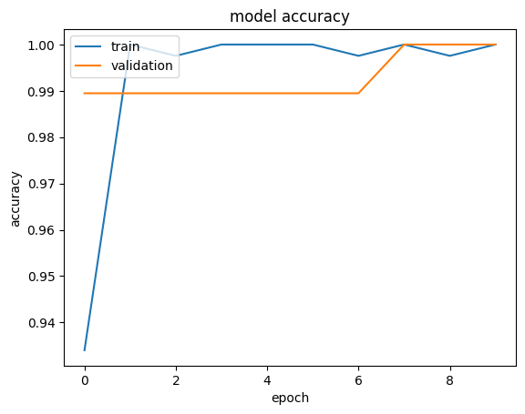

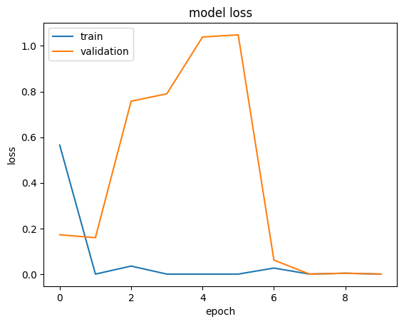

```python
# accuracy plot
plt.plot(history_4.history['accuracy'])
plt.plot(history_4.history['val_accuracy'])
plt.title('model accuracy')
plt.ylabel('accuracy')
plt.xlabel('epoch')
plt.legend(['train', 'validation'], loc='upper left')
plt.show()

# loss plot
plt.plot(history_4.history['loss'])
plt.plot(history_4.history['val_loss'])
plt.title('model loss')
plt.ylabel('loss')
plt.xlabel('epoch')
plt.legend(['train', 'validation'], loc='upper left')
plt.show()
```

***Observation: *** Model accuracy for model 4 starts at 93.5% accuracy and goes to 100% near epoch 3. There is a problem with the model loss, training loss drops to near 0.0 at epoch 1, the model is struggling to generalize mid-training despite eventually recovering.

```python
# training metrics
model_4_train_perf = model_performance_classification(model_4, X_train_vgg, pd.Series(y_train))
print("train performance metrics")
print(model_4_train_perf)

plot_confusion_matrix(model_4, X_train_vgg, pd.Series(y_train))

# validation metrics
model_4_valid_perf = model_performance_classification(model_4, X_val_vgg, pd.Series(y_val))
print("validation performance metrics")
print(model_4_valid_perf)

plot_confusion_matrix(model_4, X_val_vgg, pd.Series(y_val))
```

[output not shown]

```
14/14 ━━━━━━━━━━━━━━━━━━━━ 4s 229ms/step
train performance metrics
   Accuracy  Recall  Precision  F1 Score
0       1.0     1.0        1.0       1.0
14/14 ━━━━━━━━━━━━━━━━━━━━ 2s 171ms/step
```

```
3/3 ━━━━━━━━━━━━━━━━━━━━ 1s 392ms/step
validation performance metrics
   Accuracy  Recall  Precision  F1 Score
0       1.0     1.0        1.0       1.0
3/3 ━━━━━━━━━━━━━━━━━━━━ 1s 179ms/step
```

#### Visualizing the predictions

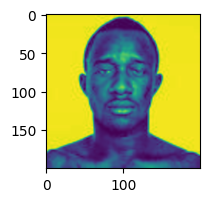

```
1/1 ━━━━━━━━━━━━━━━━━━━━ 1s 538ms/step
predicted label: 0
true label: 0
```

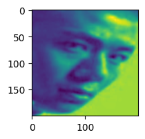

```
1/1 ━━━━━━━━━━━━━━━━━━━━ 0s 39ms/step
predicted label: 0
true label: 0
```

```python
# prediction 1 - index 10
plt.figure(figsize=(2, 2))
plt.imshow(X_val[10])
plt.show()

pred = model_4.predict(X_val_vgg[10].reshape(1, X_val_vgg.shape[1], X_val_vgg.shape[2], X_val_vgg.shape[3]))
pred_label = 1 if pred[0][0] > 0.5 else 0
true_label = y_val[10]

print('predicted label:', pred_label)
print('true label:', true_label)

# prediction 2 - index 30
plt.figure(figsize=(2, 2))
plt.imshow(X_val[30])
plt.show()

pred = model_4.predict(X_val_vgg[30].reshape(1, X_val_vgg.shape[1], X_val_vgg.shape[2], X_val_vgg.shape[3]))
pred_label = 1 if pred[0][0] > 0.5 else 0
true_label = y_val[30]

print('predicted label:', pred_label)
print('true label:', true_label)
```

***Observations: *** Both imnages were predicted correctly.

# **Model Performance Comparison and Final Model Selection**

```python
# training performance comparison

models_train_comp_df = pd.concat(
    [
        model_1_train_perf.T,
        model_2_train_perf.T,
        model_3_train_perf.T,
        model_4_train_perf.T,
    ],
    axis=1,
)
models_train_comp_df.columns = [
    "Simple Convolutional Neural Network (CNN)","VGG-16 (Base)","VGG-16 (Base+FFNN)","VGG-16 (Base+FFNN+Data Aug)"
]
```

```python
models_valid_comp_df = pd.concat(
    [
        model_1_valid_perf.T,
        model_2_valid_perf.T,
        model_3_valid_perf.T,
        model_4_valid_perf.T

    ],
    axis=1,
)
models_valid_comp_df.columns = [
 "Simple Convolutional Neural Network (CNN)","VGG-16 (Base)","VGG-16 (Base+FFNN)","VGG-16 (Base+FFNN+Data Aug)"
]
```

```python
models_train_comp_df
```

|  | Simple Convolutional Neural Network (CNN) | VGG-16 (Base) | VGG-16 (Base+FFNN) | VGG-16 (Base+FFNN+Data Aug) |
| --- | --- | --- | --- | --- |
| Accuracy | 1.0 | 1.0 | 1.0 | 1.0 |
| Recall | 1.0 | 1.0 | 1.0 | 1.0 |
| Precision | 1.0 | 1.0 | 1.0 | 1.0 |
| F1 Score | 1.0 | 1.0 | 1.0 | 1.0 |

```python
models_valid_comp_df
```

|  | Simple Convolutional Neural Network (CNN) | VGG-16 (Base) | VGG-16 (Base+FFNN) | VGG-16 (Base+FFNN+Data Aug) |
| --- | --- | --- | --- | --- |
| Accuracy | 0.989474 | 1.0 | 1.0 | 1.0 |
| Recall | 0.989474 | 1.0 | 1.0 | 1.0 |
| Precision | 0.989693 | 1.0 | 1.0 | 1.0 |
| F1 Score | 0.989474 | 1.0 | 1.0 | 1.0 |

```python
models_train_comp_df - models_valid_comp_df
```

|  | Simple Convolutional Neural Network (CNN) | VGG-16 (Base) | VGG-16 (Base+FFNN) | VGG-16 (Base+FFNN+Data Aug) |
| --- | --- | --- | --- | --- |
| Accuracy | 0.010526 | 0.0 | 0.0 | 0.0 |
| Recall | 0.010526 | 0.0 | 0.0 | 0.0 |
| Precision | 0.010307 | 0.0 | 0.0 | 0.0 |
| F1 Score | 0.010526 | 0.0 | 0.0 | 0.0 |

## Test Performance

```python
model_test_perf = model_performance_classification(model_4, X_test_vgg, pd.Series(y_test))
```

```
3/3 ━━━━━━━━━━━━━━━━━━━━ 1s 180ms/step
```

```python
model_test_perf
```

|  | Accuracy | Recall | Precision | F1 Score |
| --- | --- | --- | --- | --- |
| 0 | 1.0 | 1.0 | 1.0 | 1.0 |

```python
model_test_perf = model_performance_classification(model_4, X_test_vgg, pd.Series(y_test))
print("Test performance metrics")
print(model_test_perf)
plot_confusion_matrix(model_4, X_test_vgg,pd.Series(y_test))
```

[output not shown]

```
3/3 ━━━━━━━━━━━━━━━━━━━━ 1s 180ms/step
Test performance metrics
   Accuracy  Recall  Precision  F1 Score
0       1.0     1.0        1.0       1.0
3/3 ━━━━━━━━━━━━━━━━━━━━ 1s 179ms/step
```

# **Actionable Insights & Recommendations**

Power Ahead!